# DOCUMENTO RESUMEN Caracterización Territorial Servicios Locales de Educación Pública Barrancas

Gerardo Casas-Cordero

12-01-2022

# 1 Caracterización General del territorio del Servicio Local de Educación Pública Barrancas

## 1.1 Resumen de antecedentes generales del territorio

De conformidad a la Ley N° 21.040 que crea el sistema de Educación Pública, el Servicio Local de Educación Pública Barrancas (en adelante, SLEP o Servicio Local), con futuro domicilio en la comuna de **Pudahuel**, asumirá la responsabilidad de encargarse de la administración y gestión de **54 Establecimientos Educacionales** (en adelante, EE) y **23 Jardines Infantiles** (en adelante, JI) que componen 3 comunas de la Región RM, 13, las cuales se detallan en la siguiente tabla:

Table 1.1: Antecedentes generales del territorio

| Nombre del SLEP | Barrancas |
| --- | --- |
| Región | RM |
| Año proyectado de entrada en funcionamiento | 2018 |
| Año proyectado traspaso de sostenedor | 2019 |
| Comunas del SLEP | LO PRADO, CERRO NAVIA, PUDAHUEL |

Table 1.2: Antecedentes generales del territorio

| Nombre del SLEP | Barrancas |
| --- | --- |
| Población Total 2021 | 503.316 |
| Población Edad Escolar 2021 | 83.379 |
| Matrícula Municipal 2021 | 22.023 |
| EE Municipales 2021 | 54 |
| JI VTF Municipal | 23 |

Base utilizada: Matrícula Oficial 2021 y Directorio de EE Oficial.  
Fuente: Unidad de Estadísticas, Centro de Estudios, División de Planificación y Presupuesto, Ministerio de Educación.

**Nota:**

- Se consideran establecimientos en funcionamiento y con matrícula asociada.
- VTF: Vía Transferencia de Fondos.
- Población en edad escolar: niños entre 6 y 18 años.

## 1.2 Mapa del Territorio del SLEP Barrancas y comunas que lo componen

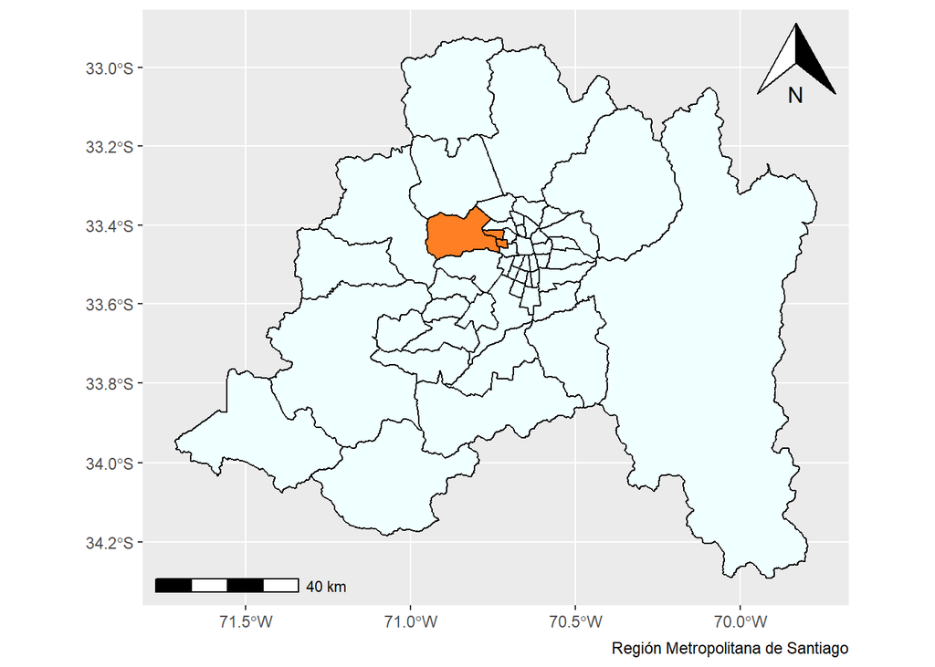

Figure 1.1: Mapa Región del SLEP

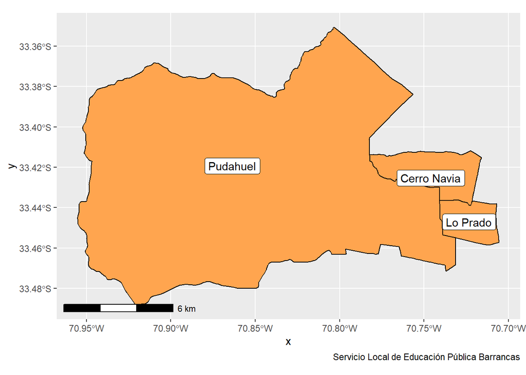

Figure 1.2: Mapa de las comunas que componen el SLEP

## 1.4 Vulnerabilidad en el Territorio

El Índice de Vulnerabilidad Escolar (IVE) se obtiene a partir de los registros del Sistema Nacional de Asignación con Equidad (SINAE), el cual consiste en la evaluación de un conjunto de criterios que permiten identificar distintos grupos dentro de la población de estudiantes de la educación básica y media de acuerdo con el nivel de vulnerabilidad que presentan.

Por lo tanto, se entiende como **alumnos vulnerables**, aquellos que se encuentran clasificados en uno de los 3 niveles de prioridad de atención de necesidades establecidas por el SINAE.

Table 1.3: Índice de Vulnerabilidad Escolar (IVE) en el territorio, año 2021

| Comuna | N° Estudiantes Vulnerables | N° Estudiantes No Vulnerables | S/I | IVE(%) |
| --- | --- | --- | --- | --- |
| Cerro Navia | 11.945 | 1.100 | 308 | 89.46 |
| Lo Prado | 8.325 | 1.168 | 367 | 84.43 |
| Pudahuel | 21.945 | 3.288 | 371 | 85.71 |

Fuente: IVE SINAE 2021

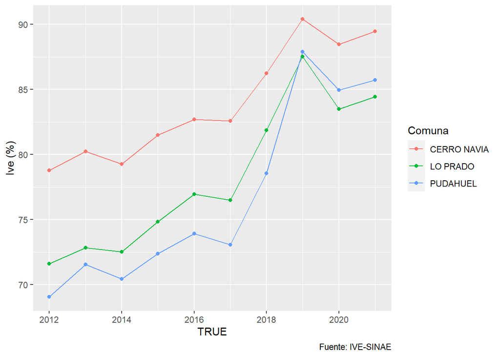

Figure 1.3: Índice de Vulnerabilidad (IVE) en las comunas pertenecientes al SLEP

Vulnerabilidad en estudiantes pertenecientes a establecimientos de dependencia municipal:

Table 1.4: Índice de Vulnerabilidad Escolar (IVE) en establecimientos municipales, año 2021

| Comuna | Vulnerables | No Vulnerables | S/I | Total | IVE(%) |
| --- | --- | --- | --- | --- | --- |
| Cerro Navia | 4.674 | 380 | 201 | 5.255 | 88.94 |
| Lo Prado | 3.914 | 393 | 267 | 4.574 | 85.57 |
| Pudahuel | 7.380 | 651 | 191 | 8.222 | 89.76 |

Fuente: IVE SINAE 2021

### 1.4.1 Estudiantes Prioritarios y Preferentes

Con el objetivo de mejorar la calidad de la educación de los establecimientos educacionales subvencionados se crea la Ley N° 20.248 de Subvención Escolar Preferencial (en adelante, Ley SEP), que tiene por objetivo entregar recursos económicos a los establecimientos educacionales de acuerdo a la cantidad de **alumnos prioritarios y preferentes** matriculados, y que, además, cumplan con los requisitos, objetivos y requerimientos establecidos en la Ley SEP. Para estos efectos, se definen:

- **Estudiantes Prioritarios:** Son aquellos quienes tienen una situación socioeconómica en sus hogares que le pueden dificultar su proceso educativo, según los criterios establecidos en el artículo 2° de Ley SEP.
- **Estudiantes preferentes:** Son aquellos que **no** tienen calidad de alumno prioritario y cuyas familias pertenecen al 80% más vulnerable de la población. Según el instrumento de caracterización social vigente (Registro Social de Hogares).

Table 1.5: Estudiantes Prioritarios y Preferentes en EE públicos del territorio, año 2020

| Comuna | Preferentes | Prioritarios | Total | Beneficiarios | Estudiantes Vulnerables(%) |
| --- | --- | --- | --- | --- | --- |
| CERRO NAVIA | 1.257 | 4.330 | 5.587 | 5.107 | 85.95 |
| LO PRADO | 1.348 | 3.167 | 4.515 | 4.132 | 77.15 |
| PUDAHUEL | 2.690 | 5.931 | 8.621 | 8.313 | 89.14 |

Nota: Porcentaje de estudiantes vulnerables corresponde a la suma de los estudiantes prioritarios y preferentes sobre la matrícula municipal por comuna  
Fuente: Datos Abiertos Mineduc, Base SEP 2020

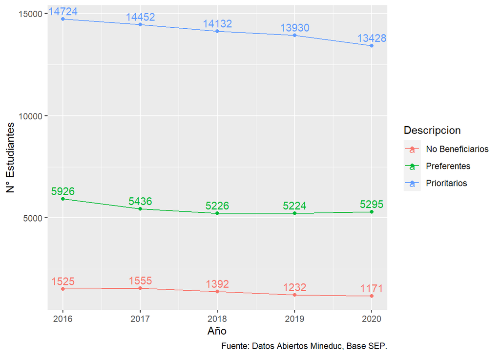

Figure 1.4: Evolución del número de estudiantes preferentes, prioritarios y no beneficiarios

### 1.4.2 Estudiantes PIE

Table 1.6: Estudiantes beneficiarios Programa Integración Escolar (PIE), año 2021

| Comuna | Beneficiarios | Beneficiarios(%) |
| --- | --- | --- |
| CERRO NAVIA | 1.135 | 17.46 |
| LO PRADO | 876 | 14.97 |
| PUDAHUEL | 1.239 | 12.81 |

Nota: Porcentaje de estudiantes beneficiarios corresponde a la suma de los estudiantes beneficiarios PIE sobre la matrícula municipal por comuna  
Base utilizada: Matrícula Oficial por Estudiante, año 2021  
Fuente: Centro de Estudios, Ministerio de Educación

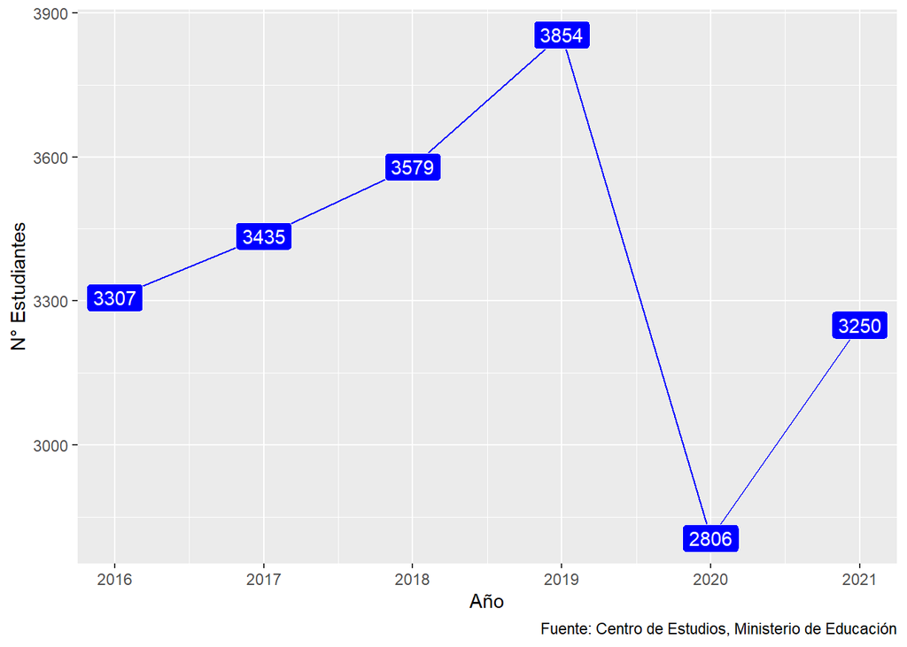

Figure 1.5: Evolución del número de alumnos beneficiarios Programa Integración Escolar (PIE)

## 1.5 Proyecciones de población en el territorio

El territorio de Barrancas tiene 503.316 habitantes proyectados al 2021, correspondiente al 6.1% de la población regional, de estos un 24.2% (121.644 habitantes) corresponde a la población entre 0-18 años.

La distribución de edad nos revela la mayor concentración de personas en el tramo Poblacion de 6-13 años con un total de 52.232 habitantes proyectados al año 2021, como se muestra en la tabla de distribución de la proyección de la población por tramos de edad hasta los 18 años en el territorio del Servicio Local.

Table 1.7: Distribución de la Proyección de población por tramos de edad por comuna, año 2021

| Comuna | Poblacion de 0-3 años | Poblacion de 4-5 años | Poblacion de 6-13 años | Poblacion de 14-18 años | Poblacion de 0-18 años |
| --- | --- | --- | --- | --- | --- |
| CERRO NAVIA | 7.096 | 3.546 | 14.417 | 8.886 | 33.945 |
| LO PRADO | 4.709 | 2.363 | 9.774 | 5.944 | 22.790 |
| PUDAHUEL | 13.508 | 7.043 | 28.041 | 16.317 | 64.909 |

Fuente: CENSO 2017 – INE. Estimaciones y proyecciones 2002 - 2035

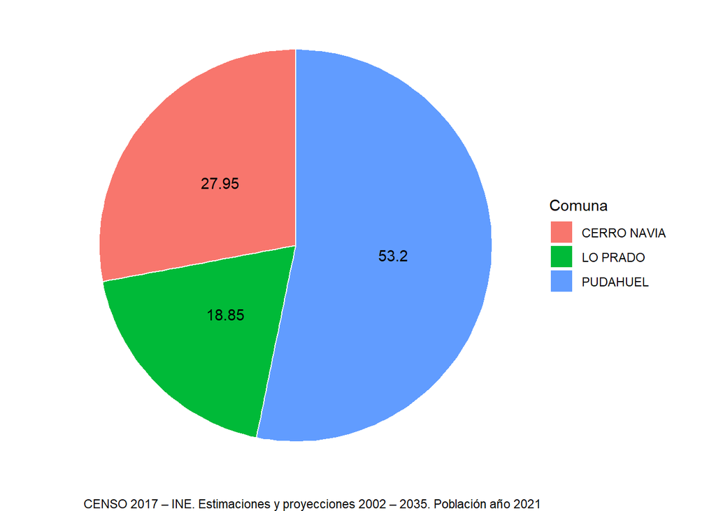

Figure 1.6: Distribución en porcentaje de la población en edad escolar (entre 6 y 18 años) por comuna

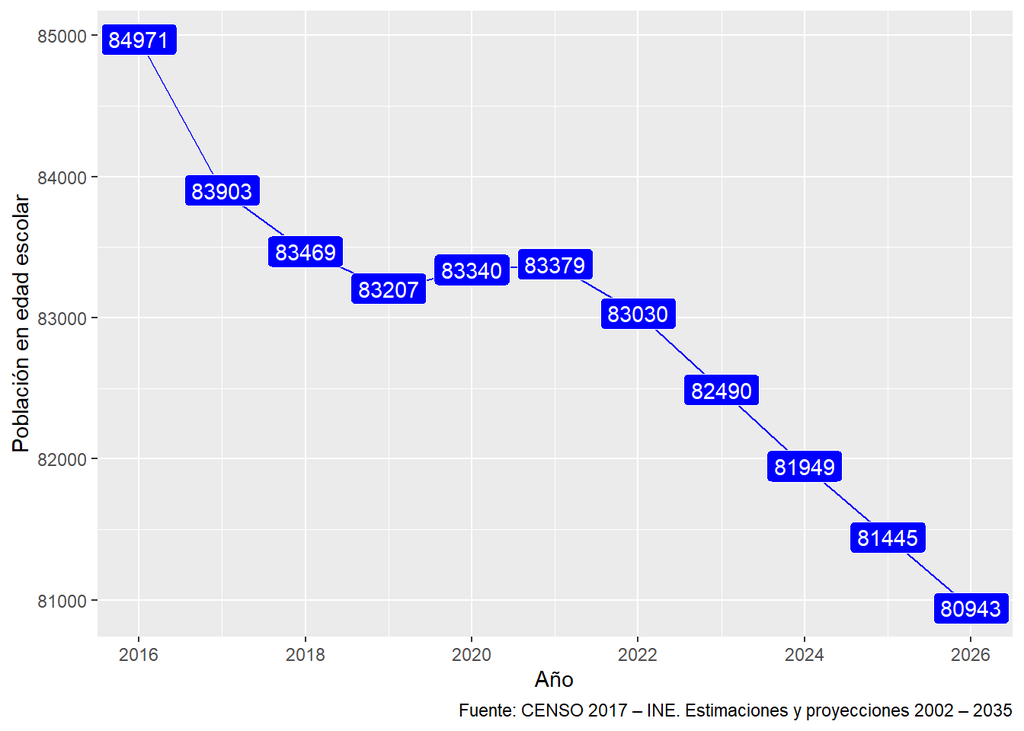

Figure 1.7: Proyecciones de población en edad escolar (entre 6 y 18 años) en el territorio del SLEP

Table 1.8: Proyección de la población en edad escolar (entre 6 y 18 años) por comuna.

| Comunas | 2016 | 2017 | 2018 | 2019 | 2020 | 2021 | 2022 | 2023 | 2024 | 2025 | 2026 |
| --- | --- | --- | --- | --- | --- | --- | --- | --- | --- | --- | --- |
| CERRO NAVIA | 24.631 | 24.116 | 23.840 | 23.635 | 23.498 | 23.303 | 23.036 | 22.726 | 22.422 | 22.133 | 21.853 |
| LO PRADO | 16.330 | 16.053 | 15.934 | 15.866 | 15.843 | 15.718 | 15.500 | 15.257 | 15.013 | 14.785 | 14.553 |
| PUDAHUEL | 44.010 | 43.734 | 43.695 | 43.706 | 43.999 | 44.358 | 44.494 | 44.507 | 44.514 | 44.527 | 44.537 |
| TOTAL | 84.971 | 83.903 | 83.469 | 83.207 | 83.340 | 83.379 | 83.030 | 82.490 | 81.949 | 81.445 | 80.943 |

Fuente: CENSO 2017 – INE. Estimaciones y proyecciones 2002 – 2035.

# 2 Caracterización de la Oferta Educativa en el territorio del Servicio Local de Educación Pública Barrancas

## 2.1 Resumen Oferta de Educación Pública en el territorio

El territorio del Servicio Local de Educación Pública Barrancas posee una oferta educativa de 143 establecimientos educacionales distribuidos de la siguiente forma: 54 establecimientos de administración Municipal o pública , 88 establecimientos de administración Subvencionada , 1 establecimientos de administración Privada

Respecto a la distribución de la matrícula, se tiene que un 34.8% de los estudiantes pertenecen a establecimientos municipales o públicos , 62.9% pertenecen a establecimientos Subvencionados , 2.3% pertenecen a establecimientos Privados

Table 2.1: Resumen Oferta Educativa del territorio

| Matrícula total 2021 | 63.339 |
| --- | --- |
| Variación matrícula 2012-2021 | -5.77% |
| Matrícula rural 2021 | 1.137 |
| Establecimientos 2021 | 143 |
| Establecimientos rurales 2021 | 3 |

Table 2.2: Resumen Oferta Municipal o Pública del SLEP

| Matrícula total 2021 | 22.023 |
| --- | --- |
| Variación matrícula 2012-2021 | -15.31% |
| Matrícula rural 2021 | 1.137 |
| Establecimientos 2021 | 54 |
| Establecimientos rurales 2021 | 3 |

Fuente: Datos Abiertos Mineduc. Base utilizada: Resumen matrícula por EE. Nota 1: Se consideran establecimientos en funcionamiento y con matrícula. Nota 2: No se consideran Jardines infantiles administrados por JUNJI, VTF y Fundación integra.

Table 2.3: Porcentaje de distribución de matrícula y establecimientos públicos por área de emplazamiento y comuna, no incluye jardines infantiles.

| Tipo | Matricula | Establecimientos |
| --- | --- | --- |
| Rurales | 5.16 | 5.56% |
| Urbanos | 94.84 | 94.44% |

Base utilizada: Matrícula y establecimiento oficial año 2021  
Fuente: Centro de Estudios, Ministerio de Educación

## 2.2 Matrícula en el territorio y su evolución en el tiempo

Table 2.4: Matrícula según dependencia por comuna, año 2021

| Comuna | Municipal/Público | Particular Pagado | Particular Subvencionado | Total |
| --- | --- | --- | --- | --- |
| CERRO NAVIA | 6.500 | 0 | 10.740 | 17.240 |
| LO PRADO | 5.852 | 0 | 6.780 | 12.632 |
| PUDAHUEL | 9.671 | 1.451 | 22.345 | 33.467 |
| Total | 22.023 | 1.451 | 39.865 | 63.339 |

Nota: Se consideran establecimientos en funcionamiento y con matrícula.  
Base utilizada: Matrícula oficial año 2021  
Fuente: Datos Abiertos Mineduc.

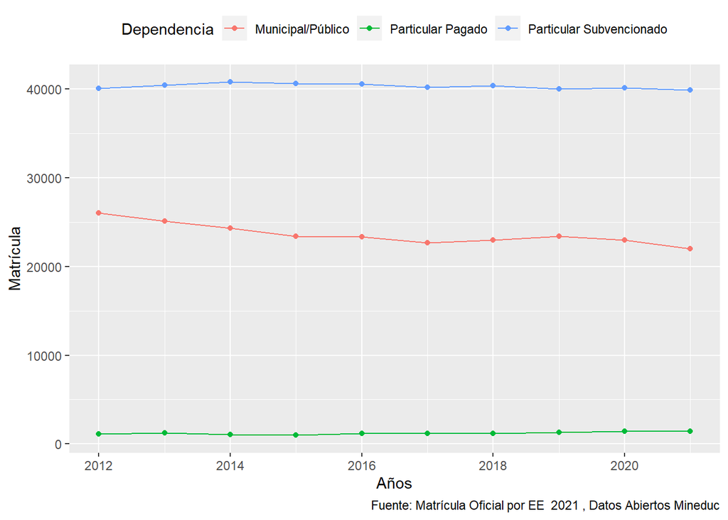

Figure 2.1: Evolución de la Matrícula por dependencia

**Nota:** Se consideran establecimientos en funcionamiento y con matrícula.

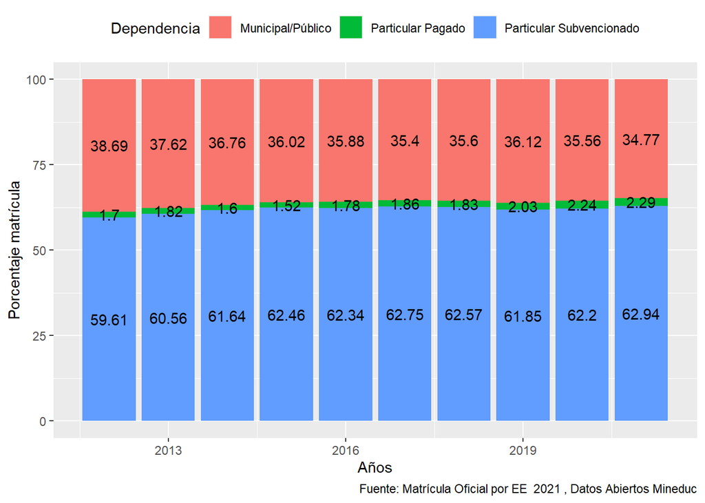

Figure 2.2: Participación de la Matrícula por dependencia

**Nota:** Se consideran establecimientos en funcionamiento y con matrícula.

A continuación, se presenta un cuadro resumen con la variación de la matrícula en las distintas dependencias del territorio:

Table 2.5: Variación de la matricula entre el año 2021 y 2012

| Dependencia | Diferencia matrícula entre 2021 y 2012 | Porcentaje de variación de la matrícula 2021 respecto a la del año 2012 |
| --- | --- | --- |
| Municipal/Público | -3.981 | -15.31% |
| Particular Pagado | 307 | 26.84% |
| Particular Subvencionado | -202 | -0.5% |

Fuente: Matrícula Oficila por EE, Datos Abiertos Mineduc.

Para interpretar la siguiente tabla, es necesario primero definir las clasificaciones según nivel de enseñanza impartidos por los establecimientos educacionales municipales:

• Educación Parvularia: Es el primer nivel de educación formal, en donde se propone favorecer en forma sistemática, oportuna y pertinente, aprendizajes de calidad para todos los párvulos. Este nivel se imparte a través de jardines infantiles de JUNJI, Fundación Integra y establecimientos privados, en donde pueden asistir niños/as entre 85 días y 5 años de edad distribuidos en sus 6 grupos o cursos.

• Enseñanza básica niños: Es el segundo nivel de educación formal, en donde se desarrolla una formación integral abordando diferentes dimensiones como física, afectica, cognitiva, entre otras. Actualmente está compuesta por 8 cursos, pero a partir de 2027 tendrá sólo 6.

• Educación básica adultos: Es una modalidad dirigida a personas jóvenes y adultas que, por distintas razones, no iniciaron o completaron su proceso escolar. Por lo que su fin es iniciar o completar sus estudios en enseñanza básica de los estudiantes, teniendo como requisito un mínimo de 15 años.

• Educación Especial: Corresponde a una educación entregada a niños, niñas, jóvenes y adultos con necesidades específicas de apoyo educativo. Esto se realiza a través de programas de integración escolar (PIE) en los establecimientos de educación regular, escuelas especiales, y de las escuelas y aulas hospitalarias.

• Enseñanza Medio Humanista Científico, jóvenes: Pertenece al tercer nivel de educación formal, en donde los estudiantes expanden y profundizan su formación general y desarrollan conocimientos. Actualmente está compuesta por 4 cursos, pero a partir de 2027 aumentará a 6.

• Educación Media Humanista Científica adultos: Es una modalidad dirigida a personas jóvenes y adultas que, por distintas razones, no completaron su proceso escolar. Por lo que su fin es iniciar completar sus estudios en enseñanza media de los estudiantes, teniendo como requisito un mínimo de 17 años.

• Enseñanza Medio técnico profesional y artística, jóvenes: Pertenece al tercer nivel de educación formal junto a humanista científico, en donde se forman estudiantes en especialidades a que responden a necesidades del desarrollo económico de cada región y país.

• Educación Media técnico profesional y artística adultos: Es una modalidad de estudios que permite completar la educación media técnico profesional y permite la obtención de un título técnico de nivel medio, teniendo como requisito un mínimo de 17 años.

Table 2.6: Matrícula pública según nivel de enseñanza por comuna, año 2021

| Comuna | Educación Parvularia | Enseñanza Básica niños | Educación Básica Adultos | Educación Especial | Enseñanza Media HC Jovenes | Educación Media HC Adultos | Enseñanza Media TP Jovenes | Educación Media TP Adultos | Total |
| --- | --- | --- | --- | --- | --- | --- | --- | --- | --- |
| CERRO NAVIA | 706 | 4.457 | 97 | 161 | 421 | 484 | 174 | 0 | 6.500 |
| LO PRADO | 560 | 3.482 | 107 | 134 | 782 | 481 | 306 | 0 | 5.852 |
| PUDAHUEL | 1.246 | 7.135 | 0 | 0 | 663 | 285 | 201 | 141 | 9.671 |
| Total | 2.512 | 15.074 | 204 | 295 | 1.866 | 1.250 | 681 | 141 | 22.023 |

Nota: Se consideran establecimientos en funcionamiento y con matrícula.  
Fuente: Matrícula Oficial por EE, Datos Abiertos Mineduc.

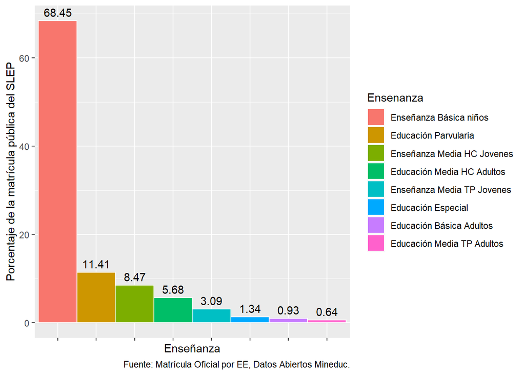

Figure 2.3: Porcentaje de matrícula Pública / Municipal por nivel de enseñanza

# 3 Establecimientos Educacionales en el territorio del Servicio Local de Educación Pública

## 3.1 Número de Establecimientos en el territorio

Table 3.1: Número de establecimientos según dependencia y por comuna, año 2021

| Comuna | Municipal/Público | Particular Pagado | Particular Subvencionado | Total |
| --- | --- | --- | --- | --- |
| CERRO NAVIA | 22 | 0 | 27 | 49 |
| LO PRADO | 13 | 0 | 18 | 31 |
| PUDAHUEL | 19 | 1 | 43 | 63 |
| Total | 54 | 1 | 88 | 143 |

Nota: Se consideran establecimientos en funcionamiento y con matrícula  
Fuente: Directorio Oficial de Establecimientos 2021 , Datos abiertos Mineduc.

| Comuna | Rural | Urbano | Total |
| --- | --- | --- | --- |
| CERRO NAVIA | 0 | 49 | 49 |
| LO PRADO | 0 | 31 | 31 |
| PUDAHUEL | 3 | 60 | 63 |
| Total | 3 | 140 | 143 |

Nota: Se consideran establecimientos en funcionamiento y con matrícula  
Fuente: Directorio Oficial de Establecimientos 2021 , Datos abiertos Mineduc.

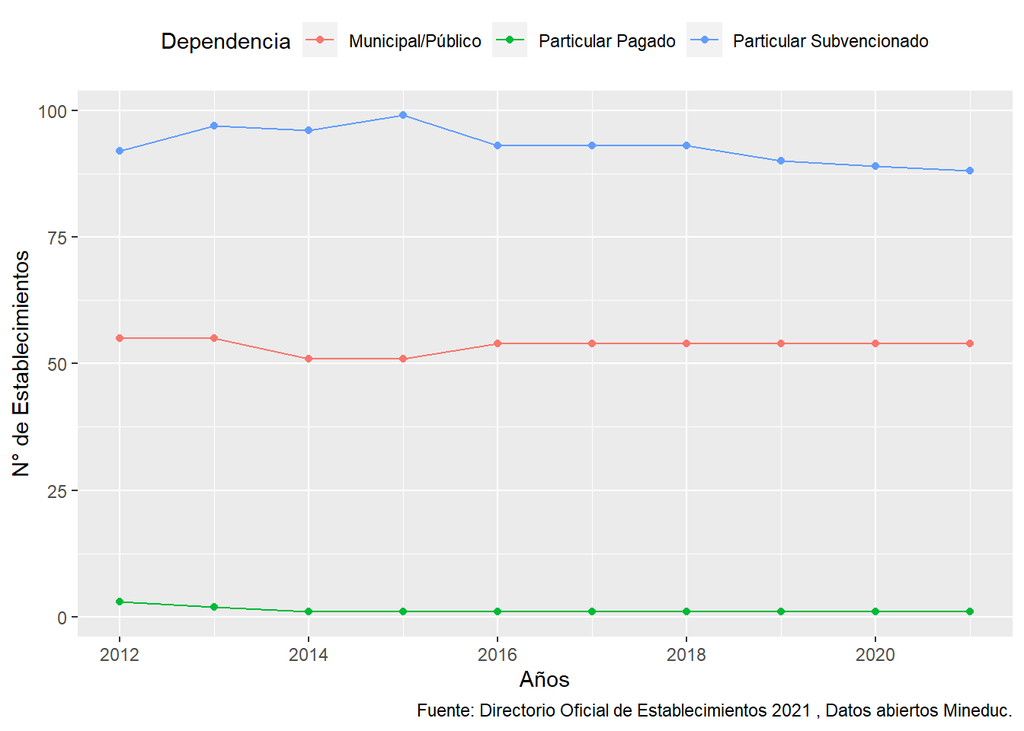

Figure 3.1: Evolución del número de establecimientos por dependencia en el territorio

**Nota:** Se consideran establecimientos en funcionamiento y con matrícula.

Con el objetivo de recopilar antecedentes para el traspaso de los establecimientos educacionales, se procede a detallar en la siguiente tabla, aquellos establecimientos educacionales de dependencia municipal/público que se encuentran en receso o han sufrido cambios en su estado de funcionamiento entre los años 2015 y 2021.

Table 3.3: Establecimientos educaciones municipales con variación en su estado de funcionamiento o en receso

| RBD | Comuna | 2015 | 2016 | 2017 | 2018 | 2019 | 2020 | 2021 |
| --- | --- | --- | --- | --- | --- | --- | --- | --- |
| 10110 | PUDAHUEL | ER | ER | ER | ER | ER | ER | ER |
| 10112 | CERRO NAVIA | ER | ER | ER | ER | ER | ER | ER |

Nota: F: Funcionando, ER: En Receso, F*: Funcionando sin matrícula, C: Cerrado  
Fuente: Directorio Oficial de Establecimientos 2021 , Datos abiertos Mineduc.

Table 3.4: Número de establecimientos municipales según cantidad de estudiantes por comuna, año 2021

| Comuna | Entre 20-149 estudiantes | Entre 150-499 estudiantes | Entre 500-799 estudiantes | Entre 800 o más estudiantes | Total |
| --- | --- | --- | --- | --- | --- |
| CERRO NAVIA | 0 | 21 | 1 | 0 | 22 |
| LO PRADO | 1 | 6 | 5 | 1 | 13 |
| PUDAHUEL | 0 | 13 | 3 | 3 | 19 |
| TOTAL | 1 | 40 | 9 | 4 | 54 |

Nota: Se consideran establecimientos en funcionamiento y con matrícula  
Fuente: Matrícula Oficial por EE 2021, Datos abiertos Mineduc.

La siguiente tabla muestra la distribución según nivel de enseñanza impartido por cada establecimiento educacional municipal del territorio. Cabe destacar que, un establecimiento educacional puede impartir más de un nivel de enseñanza.

Table 3.5: Número de establecimientos municipales según nivel de enseñanza ofrecida, año 2021

| Nivel de Enseñanza | N° de EE que imparten el nivel | Matrícula |
| --- | --- | --- |
| Educación Básica Adultos | 2 | 204 |
| Educación Especial | 2 | 295 |
| Educación Media HC Adultos | 5 | 1.250 |
| Educación Media TP y artística, Adultos | 1 | 141 |
| Educación Parvularia | 46 | 2.512 |
| Enseñanza Básica Niños | 47 | 15.074 |
| Enseñanza Media HC Jóvenes | 9 | 1.866 |
| Enseñanza Media TP y artística, Jóvenes | 4 | 681 |
| Total | NA | 22.023 |

Nota: Se consideran establecimientos en funcionamiento y con matrícula.  
Fuente: Matrícula Oficial por EE 2021, Datos abiertos Mineduc.

Table 3.6: N° de EE municipales según nivel de enseñanza ofrecida por comuna, año 2021

| Comuna | Educación Parvularia | Enseñanza Básica Niños | Educación Básica Adultos | Educación Especial | Enseñanza Media HC Jóvenes | Educación Media HC Adultos | Enseñanza Media TP y artística, Jóvenes | Educación Media TP y artística, Adultos | Total |
| --- | --- | --- | --- | --- | --- | --- | --- | --- | --- |
| CERRO NAVIA | 18 | 19 | 1 | 1 | 3 | 3 | 2 | 0 | 47 |
| LO PRADO | 11 | 11 | 1 | 1 | 3 | 1 | 1 | 0 | 29 |
| PUDAHUEL | 17 | 17 | 0 | 0 | 3 | 1 | 1 | 1 | 40 |
| Total | 46 | 47 | 2 | 2 | 9 | 5 | 4 | 1 | 116 |

Nota: Se consideran establecimientos en funcionamiento y con matrícula.  
Fuente: Matrícula Oficial por EE 2021, Datos abiertos Mineduc.

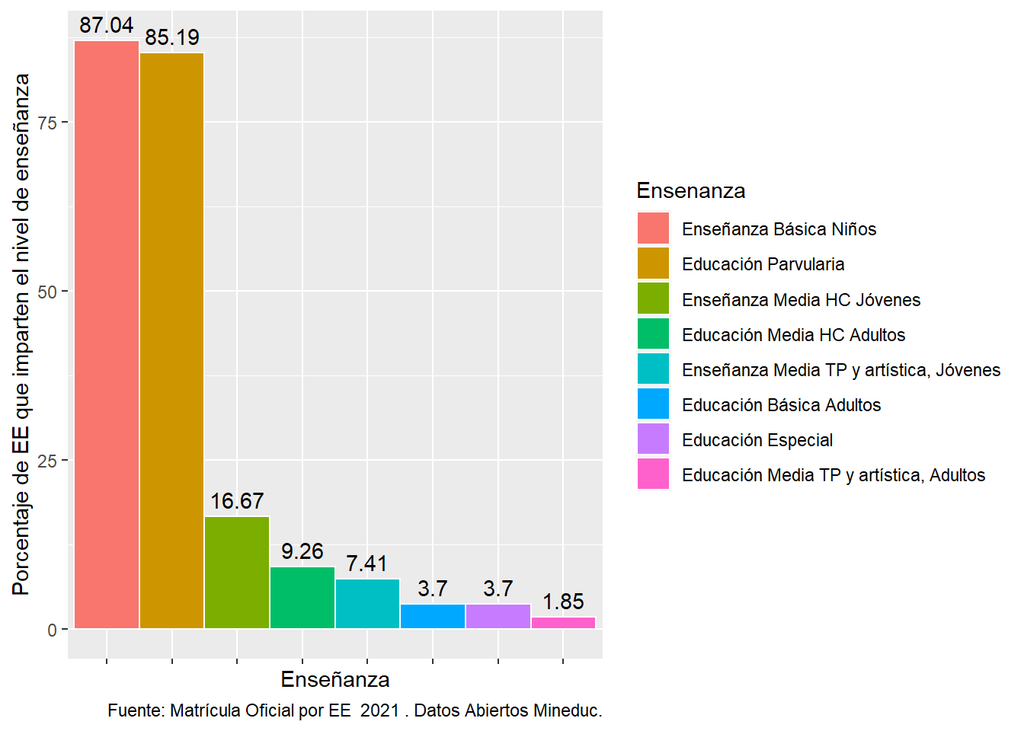

Figure 3.2: Porcentaje de EE municipales/públicos que ofrecen el nivel de enseñanza